# JHU Dataset

Ray

2024-02-19

## INTRODUCTION

The Johns Hopkins University (JHU) dataset on global COVID-19 records is a widely utilized resource containing various data points related to the COVID-19 pandemic. This dataset includes information on confirmed cases, deaths, recoveries, and more, categorized by country/region, province/state, and date. The data is valuable for monitoring the spread of the pandemic, analyzing trends, and informing public health policies.

## Data Source

Johns Hopkins University Covid-19 dataset on GITHUB. THis dataset records the amount of global cases, death and recovered over time.  
URL: https://github.com/CSSEGISandData/COVID-19/tree/master/csse_covid_19_data/csse_covid_19_time_series

## The Questions I want to address

1.Trends over time in the number of confirmed, deaths and recovered cases of Singapore  
2.Trends over time in the number of confirmed, deaths and recovered cases of Malaysia  
3.Trends over time of death rates of Singapore and Malaysia  
4.Simulate the trend of confirmed cases of Singapore

```r
confirmed_data <- read_csv("time_series_covid19_confirmed_global.csv",show_col_types = FALSE)
singapore_confirmed <- confirmed_data %>%
  filter(`Country/Region` == "Singapore")

deaths_data <- read_csv("time_series_covid19_deaths_global.csv",show_col_types = FALSE)
singapore_deaths <- deaths_data %>%
  filter(`Country/Region` == "Singapore")

recovered_data <- read_csv("time_series_covid19_recovered_global.csv",show_col_types = FALSE)
singapore_recovered <- recovered_data %>%
  filter(`Country/Region` == "Singapore")

head(singapore_confirmed[, 1:10])
```

```
## # A tibble: 1 × 10
##   `Province/State` `Country/Region`   Lat  Long `1/22/20` `1/23/20` `1/24/20`
##   <chr>            <chr>            <dbl> <dbl>     <dbl>     <dbl>     <dbl>
## 1 <NA>             Singapore         1.28  104.         0         1         3
## # ℹ 3 more variables: `1/25/20` <dbl>, `1/26/20` <dbl>, `1/27/20` <dbl>
```

```r
head(singapore_deaths[, 1:10])
```

```
## # A tibble: 1 × 10
##   `Province/State` `Country/Region`   Lat  Long `1/22/20` `1/23/20` `1/24/20`
##   <chr>            <chr>            <dbl> <dbl>     <dbl>     <dbl>     <dbl>
## 1 <NA>             Singapore         1.28  104.         0         0         0
## # ℹ 3 more variables: `1/25/20` <dbl>, `1/26/20` <dbl>, `1/27/20` <dbl>
```

```r
head(singapore_recovered[, 1:10])
```

```
## # A tibble: 1 × 10
##   `Province/State` `Country/Region`   Lat  Long `1/22/20` `1/23/20` `1/24/20`
##   <chr>            <chr>            <dbl> <dbl>     <dbl>     <dbl>     <dbl>
## 1 <NA>             Singapore         1.28  104.         0         0         0
## # ℹ 3 more variables: `1/25/20` <dbl>, `1/26/20` <dbl>, `1/27/20` <dbl>
```

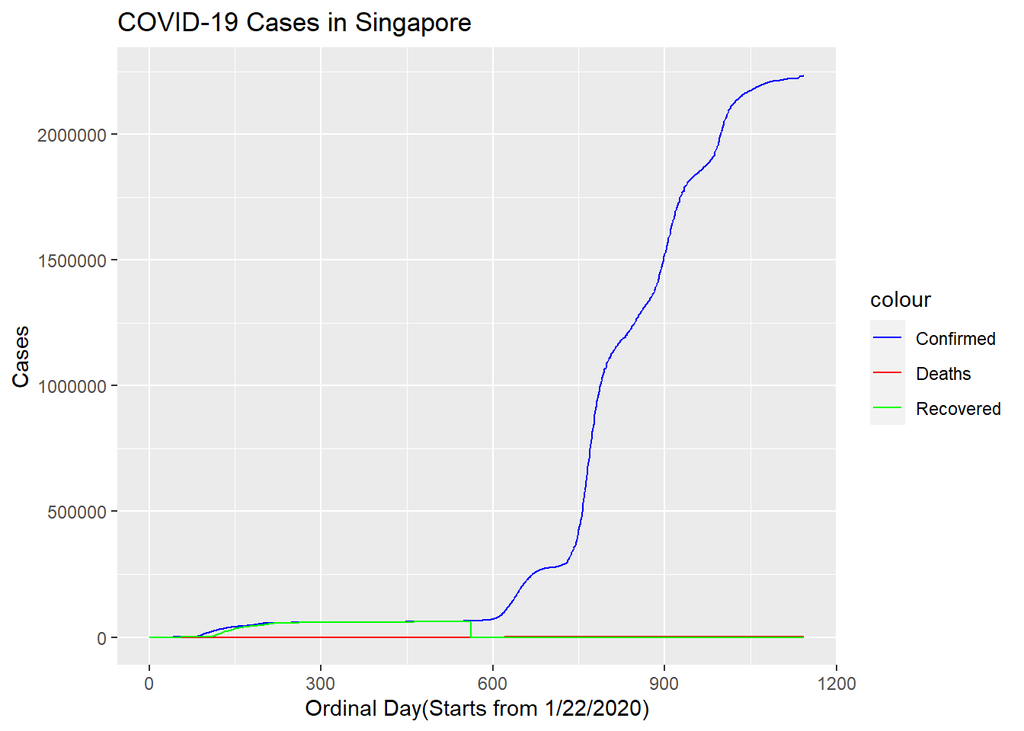

```r
library(tidyverse)

singapore_confirmed_long <- singapore_confirmed %>%
  pivot_longer(cols = -c(`Province/State`, `Country/Region`, Lat, Long),
               names_to = "Date",
               values_to = "Confirmed") %>%
  select(-c(`Province/State`, `Country/Region`, Lat, Long))

singapore_deaths_long <- singapore_deaths %>%
  pivot_longer(cols = -c(`Province/State`, `Country/Region`, Lat, Long),
               names_to = "Date",
               values_to = "Deaths") %>%
  select(-c(`Province/State`, `Country/Region`, Lat, Long))

singapore_recovered_long <- singapore_recovered %>%
  pivot_longer(cols = -c(`Province/State`, `Country/Region`, Lat, Long),
               names_to = "Date",
               values_to = "Recovered") %>%
  select(-c(`Province/State`, `Country/Region`, Lat, Long))

singapore_confirmed_long <- singapore_confirmed_long %>%
  mutate(Ordinal = row_number())

singapore_deaths_long <- singapore_deaths_long %>%
  mutate(Ordinal = row_number())

singapore_recovered_long <- singapore_recovered_long %>%
  mutate(Ordinal = row_number())

ggplot() +
  geom_line(data = singapore_confirmed_long, aes(x = Ordinal, y = Confirmed, color = "Confirmed")) +
  geom_line(data = singapore_deaths_long, aes(x = Ordinal, y = Deaths, color = "Deaths")) +
  geom_line(data = singapore_recovered_long, aes(x = Ordinal, y = Recovered, color = "Recovered")) +
  labs(x = "Ordinal Day(Starts from 1/22/2020)", y = "Cases", title = "COVID-19 Cases in Singapore") +
  scale_color_manual(values = c("Confirmed" = "blue", "Deaths" = "red", "Recovered" = "green"),
                     labels = c("Confirmed", "Deaths", "Recovered"))
```

### Analysis

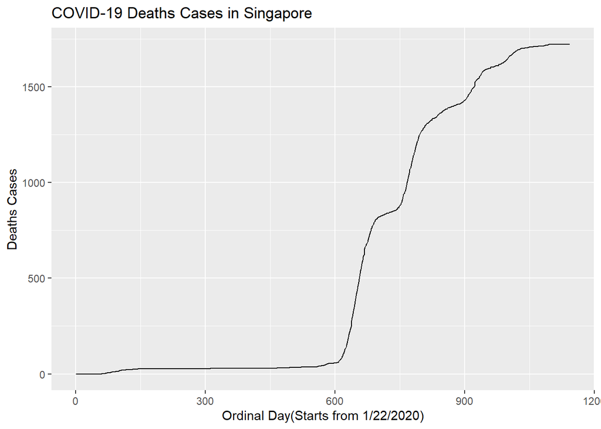

```r
library(tidyverse)

singapore_deaths_long <- singapore_deaths %>%
  pivot_longer(cols = -c(`Province/State`, `Country/Region`, Lat, Long),
               names_to = "Date",
               values_to = "Deaths") %>%
  select(-c(`Province/State`, `Country/Region`, Lat, Long))

singapore_deaths_long <- singapore_deaths_long %>%
  mutate(Ordinal = row_number())

ggplot(data = singapore_deaths_long, aes(x = Ordinal, y = Deaths)) +
  geom_line() +
  labs(x = "Ordinal Day(Starts from 1/22/2020)", y = "Deaths Cases", title = "COVID-19 Deaths Cases in Singapore")
```

### Analysis

Because the number of deaths is too small compared to the number of confirmed cases to show the trend of the number of deaths well in that graph above, I generate this graph separately to show the trend of death cases.

```r
malaysia_confirmed <- confirmed_data %>%
  filter(`Country/Region` == "Malaysia")

malaysia_deaths <- deaths_data %>%
  filter(`Country/Region` == "Malaysia")

malaysia_recovered <- recovered_data %>%
  filter(`Country/Region` == "Malaysia")

head(malaysia_confirmed[, 1:10])
```

```
## # A tibble: 1 × 10
##   `Province/State` `Country/Region`   Lat  Long `1/22/20` `1/23/20` `1/24/20`
##   <chr>            <chr>            <dbl> <dbl>     <dbl>     <dbl>     <dbl>
## 1 <NA>             Malaysia          4.21  102.         0         0         0
## # ℹ 3 more variables: `1/25/20` <dbl>, `1/26/20` <dbl>, `1/27/20` <dbl>
```

```r
head(malaysia_deaths[, 1:10])
```

```
## # A tibble: 1 × 10
##   `Province/State` `Country/Region`   Lat  Long `1/22/20` `1/23/20` `1/24/20`
##   <chr>            <chr>            <dbl> <dbl>     <dbl>     <dbl>     <dbl>
## 1 <NA>             Malaysia          4.21  102.         0         0         0
## # ℹ 3 more variables: `1/25/20` <dbl>, `1/26/20` <dbl>, `1/27/20` <dbl>
```

```r
head(malaysia_recovered[, 1:10])
```

```
## # A tibble: 1 × 10
##   `Province/State` `Country/Region`   Lat  Long `1/22/20` `1/23/20` `1/24/20`
##   <chr>            <chr>            <dbl> <dbl>     <dbl>     <dbl>     <dbl>
## 1 <NA>             Malaysia          4.21  102.         0         0         0
## # ℹ 3 more variables: `1/25/20` <dbl>, `1/26/20` <dbl>, `1/27/20` <dbl>
```

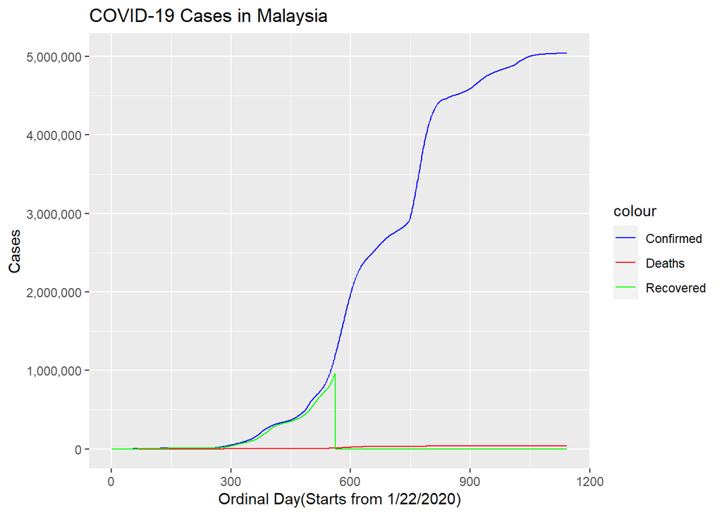

```r
malaysia_confirmed_long <- malaysia_confirmed %>%
  pivot_longer(cols = -c(`Province/State`, `Country/Region`, Lat, Long),
               names_to = "Date",
               values_to = "Confirmed") %>%
  select(-c(`Province/State`, `Country/Region`, Lat, Long))

malaysia_deaths_long <- malaysia_deaths %>%
  pivot_longer(cols = -c(`Province/State`, `Country/Region`, Lat, Long),
               names_to = "Date",
               values_to = "Deaths") %>%
  select(-c(`Province/State`, `Country/Region`, Lat, Long))

malaysia_recovered_long <- malaysia_recovered %>%
  pivot_longer(cols = -c(`Province/State`, `Country/Region`, Lat, Long),
               names_to = "Date",
               values_to = "Recovered") %>%
  select(-c(`Province/State`, `Country/Region`, Lat, Long))

malaysia_confirmed_long <- malaysia_confirmed_long %>%
  mutate(Ordinal = row_number())

malaysia_deaths_long <- malaysia_deaths_long %>%
  mutate(Ordinal = row_number())

malaysia_recovered_long <- malaysia_recovered_long %>%
  mutate(Ordinal = row_number())

ggplot() +
  geom_line(data = malaysia_confirmed_long, aes(x = Ordinal, y = Confirmed, color = "Confirmed")) +
  geom_line(data = malaysia_deaths_long, aes(x = Ordinal, y = Deaths, color = "Deaths")) +
  geom_line(data = malaysia_recovered_long, aes(x = Ordinal, y = Recovered, color = "Recovered")) +
  labs(x = "Ordinal Day(Starts from 1/22/2020)", y = "Cases", title = "COVID-19 Cases in Malaysia") +
  scale_color_manual(values = c("Confirmed" = "blue", "Deaths" = "red", "Recovered" = "green"),
                     labels = c("Confirmed", "Deaths", "Recovered")) +
  scale_y_continuous(labels = scales::comma)
```

### Analysis

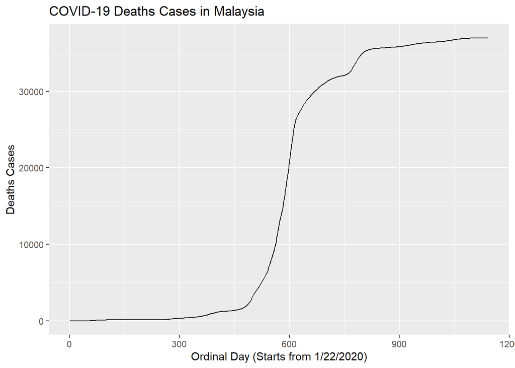

```r
malaysia_deaths_long <- malaysia_deaths %>%
  pivot_longer(cols = -c(`Province/State`, `Country/Region`, Lat, Long),
               names_to = "Date",
               values_to = "Deaths") %>%
  select(-c(`Province/State`, `Country/Region`, Lat, Long))

malaysia_deaths_long <- malaysia_deaths_long %>%
  mutate(Ordinal = row_number())

ggplot(data = malaysia_deaths_long, aes(x = Ordinal, y = Deaths)) +
  geom_line() +
  labs(x = "Ordinal Day (Starts from 1/22/2020)", y = "Deaths Cases", title = "COVID-19 Deaths Cases in Malaysia")
```

### Analysis

Because the number of deaths is too small compared to the number of confirmed cases to show the trend of the number of deaths well in that graph above, I generate this graph separately to show the trend of death cases.

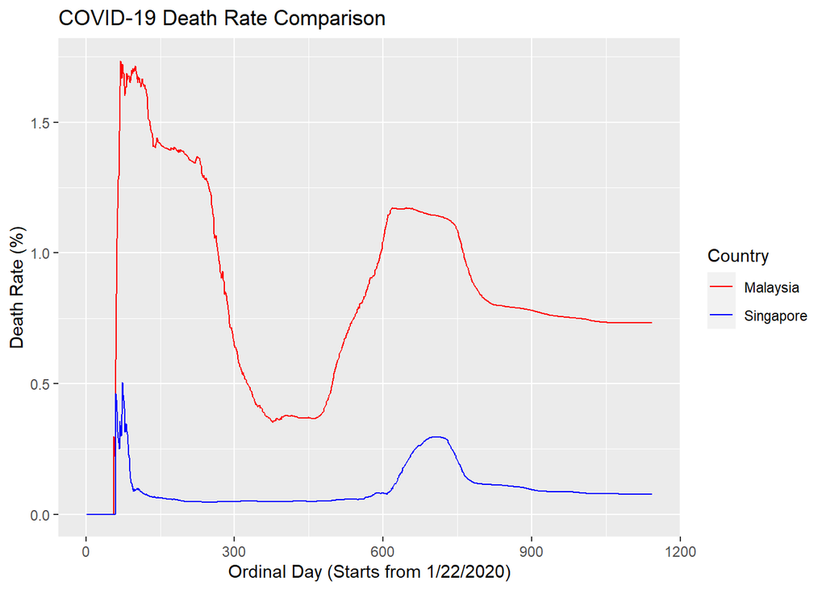

```r
singapore_death_rate <- singapore_deaths %>%
  select(-c(`Province/State`, `Country/Region`, Lat, Long)) / singapore_confirmed %>%
  select(-c(`Province/State`, `Country/Region`, Lat, Long)) * 100
malaysia_death_rate <- malaysia_deaths %>%
  select(-c(`Province/State`, `Country/Region`, Lat, Long)) / malaysia_confirmed %>%
  select(-c(`Province/State`, `Country/Region`, Lat, Long)) * 100



# 添加序数列
singapore_death_rate <- singapore_death_rate %>%
  mutate(Ordinal = 1:n())

malaysia_death_rate <- malaysia_death_rate %>%
  mutate(Ordinal = 1:n())

# 转换为长格式
singapore_death_rate_long <- singapore_death_rate %>%
  pivot_longer(cols = -c(Ordinal), names_to = "Date", values_to = "Death_Rate")

malaysia_death_rate_long <- malaysia_death_rate %>%
  pivot_longer(cols = -c(Ordinal), names_to = "Date", values_to = "Death_Rate")


singapore_death_rate_long <- singapore_death_rate_long %>%
  mutate_at(vars(Ordinal), list(~c(1:n())))


malaysia_death_rate_long <- malaysia_death_rate_long %>%
  mutate_at(vars(Ordinal), list(~c(1:n())))

combined_rate_data <- bind_rows(
  mutate(singapore_death_rate_long, Country = "Singapore"),
  mutate(malaysia_death_rate_long, Country = "Malaysia")
)


ggplot(data = combined_rate_data, aes(x = Ordinal, y = Death_Rate, color = Country)) +
  geom_line() +
  labs(x = "Ordinal Day (Starts from 1/22/2020)", y = "Death Rate (%)", title = "COVID-19 Death Rate Comparison") +
  scale_color_manual(values = c("Singapore" = "blue", "Malaysia" = "red"))
```

### Analysis

At the beginning, people did not know how to face SARS-Cov-2, one the one hand, we did not control the trend of increase, on the other hand, the death rates reached the peak in both Malaysia and Singapore. Around 680 days later, Omicron appeared. The sharp rise in the number of confirmed cases overcrowded hospitals and caused a medical run, so the death rate peaked for the second time. Singapore’s mortality rate is better controlled than that of its neighboring country, Malaysia, because of better medical care and a higher level of social development.

## Model

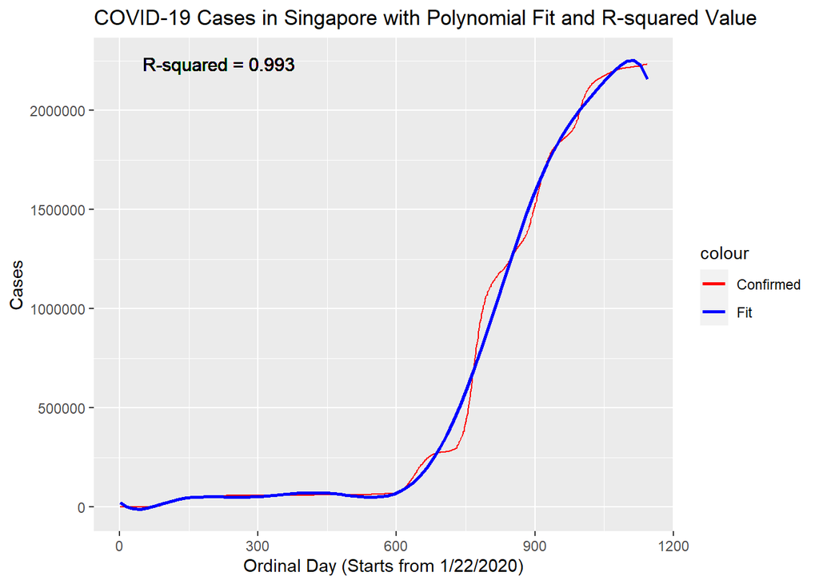

```r
library(tidyverse)

singapore_confirmed_long <- singapore_confirmed %>%
  pivot_longer(cols = -c(`Province/State`, `Country/Region`, Lat, Long),
               names_to = "Date",
               values_to = "Confirmed") %>%
  select(-c(`Province/State`, `Country/Region`, Lat, Long)) %>%
  mutate(Ordinal = row_number())

fit <- lm(Confirmed ~ poly(Ordinal, 6), data = singapore_confirmed_long)

r_squared <- summary(fit)$r.squared

ggplot(data = singapore_confirmed_long, aes(x = Ordinal, y = Confirmed)) +
  geom_line(aes(color = "Confirmed"), show.legend = TRUE) +
  geom_smooth(aes(color = "Fit"), method = "lm", formula = y ~ poly(x, 10), se = FALSE) +
  geom_text(x = 50, y = max(singapore_confirmed_long$Confirmed),
            label = paste("R-squared =", round(r_squared, 3)),
            color = "black", size = 4, hjust = 0) +
  labs(x = "Ordinal Day (Starts from 1/22/2020)", y = "Cases",
       title = "COVID-19 Cases in Singapore with Polynomial Fit and R-squared Value") +
  scale_color_manual(values = c("red", "blue"),
                     labels = c("Confirmed", "Fit"))
```

### Analysis

I deploy a polynomial function to simulate the trend of confirmed cases of Singapore. Because the number of confirmed cases is affected by the number of tests, the capacity of the tests, and the strength of the government’s out-of-home restraining order, it doesn’t change at an increasing rate all the time, but fluctuates. I control the degree of polynomial regression to avoid overfitting.

## Conclusion and possible sources of bias

Conclusion: Overall, the trends in the number of confirmed, recovered and fatal cases were similar in Singapore and Malaysia. However, the number of confirmed cases started to increase sharply later in Singapore than in Malaysia. Singapore’s mortality rate has also been almost consistently lower than Malaysia’s.